# Home

Welcome, my name is Jochem Hummel and I am a fourth year PhD student at the Knowledge, Information, and Innovation (KIN) research group at the Vrije Universiteit Amsterdam.

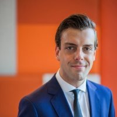

#### My Research

My research focuses on understanding the strategic mechanisms and practices used by organizations in complex multi-actor collaborations to mobilize support and pursue big goals related to digital innovation. My first priority lies with doing highly rigorous, qualitative, empirical work. For example, my dissertation research concerns a longitudinal empirical study of a collaboration between ‘big science’ and ‘big business’ called *Helix Nebula*, where I analyze how large scientific institutes (CERN, EMBL, ESA) collaborate with commercial cloud computing organizations (Atos, T-Systems), and public infrastructure providers (EGI, GEANT), to develop a European scientific cloud computing infrastructure.

My research is grounded in science and technology studies and process research, and I link my work on complex multi-actor collaborations driven by digital innovation to various literatures, including organizational pluralism, resourcing, framing, and new ways of organizing. I typically do process research, and through my interest in micro-level dynamics I also have knowledge of practice theory and its relevant methodologies. I am a passionate qualitative researcher (case study and ethnographic methods). Driven by my determination for methodological rigor I have adopted digital methods for qualitative data as a complementary analysis technique. For example, for the second empirical paper of my dissertation I use Latent Dirichlet Allocation (a topic modelling technique from computer linguistics) to extract topics from 11,000 internal text documents (e-mails, documents, presentations) and use measures from communication studies and clustering methods to analyze the relationships between topics over time.

My dedication to the academic field is broader then just my own research. For my reviewing activities, I was awarded the ABCD reviewing award of the OMT division in 2016 and 2017 – two years in a row. On top of that, in 2017 I received the TIM division reviewing award as another recognition of my dedication to academic colleagues.

#### Research Interests

**Theory**  
Complex multi-actor collaborations, organizational pluralism, organizational resourcing, framing, new ways of organizing, open innovation

**Phenomena**  
Digital innovation, science-business collaborations, platforms and ecosystems

**Methods**  
Qualitative methods, digital methods for qualitative data (topic modelling, sequence analysis, cluster analysis)

#### Teaching Interests

technology and innovation, digital innovation, qualitative research methods, digital methods for qualitative data, strategic management, open and user innovation, knowledge management, business research methods, new ways of organizing